# Gross Revenue Prediction using Liner Regression

Part II - Model Development

## 1. Objective

Objective of this project is to help a studio in priortization (such as decide which titles to fund for production, how much to bid on produced movies, when to release a title, how much to invest in marketing and PR, etc.) by investigating the relationship between the movie descriptors and the success of the movie at box office which is represented as Gross Revenue. This analysis is very valuable after the movie is already released as it can affect additional marketing spend or how much a studio should negotiate with on-demand streaming companies etc.

## 2. About Dataset

Dataset has 40K rows and 39 columns which contains information about movies, including ratings, budget, gross revenue and other attributes. It was prepared by by querying IMDb’s API (see www.omdbapi.com) and joining it with a separate dataset of movie budgets and gross earnings (unknown to you). The join key was the movie title. Each row represents a movie title and each column represents a descriptor such as Title, Actors, and Budget.

## 3 Setup & Dataset CleanUp

```r
load('movies_merged')

df = movies_merged
cat("Dataset has", dim(df)[1], "rows and", dim(df)[2], "columns", end="\n", file="")
```

```
## Dataset has 40789 rows and 39 columns
```

```r
colnames(df)
```

```
##  [1] "Title"             "Year"              "Rated"
##  [4] "Released"          "Runtime"           "Genre"
##  [7] "Director"          "Writer"            "Actors"
## [10] "Plot"              "Language"          "Country"
## [13] "Awards"            "Poster"            "Metascore"
## [16] "imdbRating"        "imdbVotes"         "imdbID"
## [19] "Type"              "tomatoMeter"       "tomatoImage"
## [22] "tomatoRating"      "tomatoReviews"     "tomatoFresh"
## [25] "tomatoRotten"      "tomatoConsensus"   "tomatoUserMeter"
## [28] "tomatoUserRating"  "tomatoUserReviews" "tomatoURL"
## [31] "DVD"               "BoxOffice"         "Production"
## [34] "Website"           "Response"          "Budget"
## [37] "Domestic_Gross"    "Gross"             "Date"
```

```r
## Load R packages

library(ggplot2)
library(dplyr)
library(stringr)

# Remove all rows from df that do not correspond to movies
df_movie = df[df$Type == "movie", ]

#Since our goal is to model `Gross` revenue against other variables, rows that have missing `Gross` values are ommitted

# Remove rows with missing Gross value
df_movie_gross = filter(df_movie, !is.na(Gross))

#Inflation and other global financial factors may affect the revenue earned by movies during certain periods of time.
#Excluding all movies that were released prior to the year 2000.
df_movie_gross_release = filter(df_movie_gross, Year >= 2000)

# Remove mismatched rows
df_movie_gross_release_match = filter(df_movie_gross_release, abs(as.numeric(substring(df_movie_gross_release$Released, 1, 4)) - df_movie_gross_release$Year) <= 1)

#Domestic_Gross is basically the amount of revenue a movie earned within the US. Understandably, it is very highly correlated with `Gross` and is in fact equal to it for movies that were not released globally. Hence, removing for modeling purposes.

df_movie_gross_release_match$Domestic_Gross <- NULL

# Replacing df$Runtime with a numeric column containing the runtime in minutes

df_movie_gross_release_match$Runtime <- gsub(" min", "", df_movie_gross_release_match$Runtime)
df_movie_gross_release_match$Runtime <- gsub(" h ", "", df_movie_gross_release_match$Runtime)
df_movie_gross_release_match$Runtime <- gsub(" h", "", df_movie_gross_release_match$Runtime)
df_movie_gross_release_match$Runtime <- as.numeric(as.character(df_movie_gross_release_match$Runtime))

# Printing the dimensions of the final preprocessed dataset and column names
dim(df_movie_gross_release_match)
```

```
## [1] 3216   38
```

```r
colnames(df_movie_gross_release_match)
```

```
##  [1] "Title"             "Year"              "Rated"
##  [4] "Released"          "Runtime"           "Genre"
##  [7] "Director"          "Writer"            "Actors"
## [10] "Plot"              "Language"          "Country"
## [13] "Awards"            "Poster"            "Metascore"
## [16] "imdbRating"        "imdbVotes"         "imdbID"
## [19] "Type"              "tomatoMeter"       "tomatoImage"
## [22] "tomatoRating"      "tomatoReviews"     "tomatoFresh"
## [25] "tomatoRotten"      "tomatoConsensus"   "tomatoUserMeter"
## [28] "tomatoUserRating"  "tomatoUserReviews" "tomatoURL"
## [31] "DVD"               "BoxOffice"         "Production"
## [34] "Website"           "Response"          "Budget"
## [37] "Gross"             "Date"
```

## 4 Model Evaluation Strategy

Build various regression models and compare their performance by computing the training and test Root Mean Squared Error (RMSE) at different training set sizes.

Randomly sampled 10-20% of the preprocessed dataset and keep that aside as the **test set**. The remainder of the preprocessed dataset is used as **training data**.

Following evaluation procedure for each model:

- Choose a suitable sequence of training set sizes, e.g. 10%, 20%, 30%, …, 100% (10-20 different sizes should suffice). For each size, sample that many inputs from the training data, train your model, and compute the resulting training and test RMSE.
- Repeat your training and evaluation at least 10 times at each training set size, and average the RMSE results for stability.
- Generate a graph of the averaged train and test RMSE values as a function of the train set size (%), with optional error bars.

### 4.1. Model 1 - Numeric variables

Use Linear Regression to predict `Gross` revenue based on available *numeric* variables.

```r
# Build & evaluate model 1 (numeric variables only)
set.seed(42)

# function to do linear regression and compute rmse
estimate <- function(training, testing) {

  model = lm(Gross~., data=training, na.action = na.omit)
  # training RMSE
  predicted_train = predict(model, training)
  predicted_train_resid = (training$Gross - predicted_train) ** 2
  predicted_train_rmse = sqrt(sum(predicted_train_resid) / dim(training)[1])

  # testing RMSE
  predicted_test = predict(model, testing)
  predicted_test_resid = (testing$Gross - predicted_test) ** 2
  predicted_test_rmse = sqrt(sum(predicted_test_resid) / dim(testing)[1])

  return(list(predicted_train_rmse, predicted_test_rmse))
}

selected_features = c("Gross", "Runtime", "imdbRating", "imdbVotes", "tomatoRating", "tomatoReviews", "tomatoFresh", "Budget" )
df_selected = subset(df_movie_gross_release_match, select = selected_features)
df_selected = df_selected[sample(nrow(df_selected)), ]

testing = df_selected[1 : (dim(df_selected)[1] * 0.2), ]
training = df_selected[(dim(df_selected)[1] * 0.2) : dim(df_selected)[1], ]
testing1 = na.omit(testing)
training1 = na.omit(training)

sample_size = c(0.1, 0.2, 0.3, 0.4, 0.5, 0.6, 0.7, 0.8, 0.9, 1)

training_rmses = matrix(0, nrow=10, ncol=10)
testing_rmses = matrix(0, nrow=10, ncol=10)

# start evaluation
for (i in 1:10) {
  # shuffle training
  training1 = training1[sample(nrow(training1)), ]
  for (j in 1:10) {
    training_cur = training1[1:round(sample_size[j] * nrow(training1)), ]
    res = estimate(training_cur, testing1)
    training_rmses[i, j] = res[[1]]
    testing_rmses[i, j] = res[[2]]
  }
}

# plot results
training_rmses = colMeans(training_rmses)
testing_rmses = colMeans(testing_rmses)

results = data.frame(cbind(sample_size, training_rmses, testing_rmses))
colnames(results) <- c("sample_size", "training_RMSEs", "testing_RMSEs")
print(min(testing_rmses))
```

```
## [1] 100820138
```

```r
print(which.min(testing_rmses))
```

```
## [1] 10
```

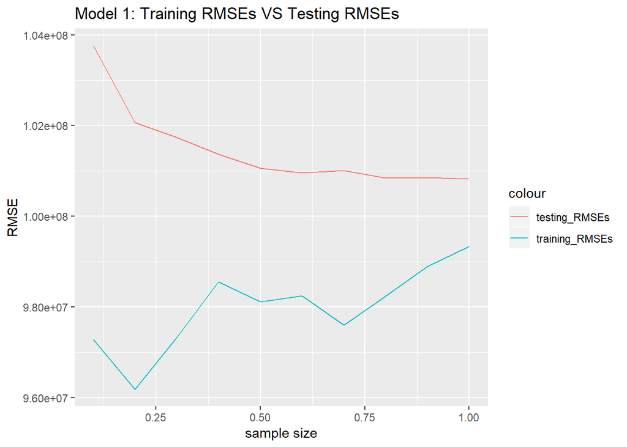

```r
ggplot(results, aes(sample_size)) +
  geom_line(aes(y=training_RMSEs, x=sample_size, colour="training_RMSEs")) +
  geom_line(aes(y=testing_RMSEs, x=sample_size, colour="testing_RMSEs")) +
  xlab("sample size") +
  ylab("RMSE") + labs(title="Model 1: Training RMSEs VS Testing RMSEs")
```

Numeric variables used: “Gross”, “Runtime”, “imdbRating”, “imdbVotes”, “tomatoRating”, “tomatoReviews”, “tomatoFresh”, “Budget”

### 4.2. Model 2 - Feature transformations

Improve the prediction quality from **Model 1** as much as possible by adding feature transformations of the numeric variables. Explore both numeric transformations such as power transforms and non-numeric transformations of the numeric variables like binning.

```r
# Build & evaluate model 2 (transformed numeric variables only)
set.seed(42)
selected_features = c("Gross", "Runtime", "imdbRating", "imdbVotes", "tomatoRating", "tomatoReviews", "tomatoFresh", "Budget" )
df_selected = subset(df_movie_gross_release_match, select = selected_features)
df_selected = df_selected[sample(nrow(df_selected)), ]

testing = df_selected[1 : (dim(df_selected)[1] * 0.2), ]
training = df_selected[(dim(df_selected)[1] * 0.2) : dim(df_selected)[1], ]
testing1 = na.omit(testing)
training1 = na.omit(training)

# feature transformation
# log transform on budget
training1$LogBudget = log(training1$Budget)
testing1$LogBudget = log(testing1$Budget)
training1$LogimdbVotes = log(training1$imdbVotes)
testing1$LogimdbVotes = log(testing1$imdbVotes)

# binning on
training1$BintomatoRating = cut(training1$tomatoRating, 5, include.lowest = TRUE, labels = c(1, 2, 3, 4, 5))
testing1$BintomatoRating = cut(testing1$tomatoRating, 5, include.lowest = TRUE, labels = c(1, 2, 3, 4, 5))

sample_size = c(0.1, 0.2, 0.3, 0.4, 0.5, 0.6, 0.7, 0.8, 0.9, 1)

training_rmses = matrix(0, nrow=10, ncol=10)
testing_rmses = matrix(0, nrow=10, ncol=10)

# start evaluation
for (i in 1:10) {
  # shuffle training
  training1 = training1[sample(nrow(training1)), ]
  for (j in 1:10) {
    training_cur = training1[1:round(sample_size[j] * nrow(training1)), ]

    res = estimate(training_cur, testing1)
    training_rmses[i, j] = res[[1]]
    testing_rmses[i, j] = res[[2]]
  }
}

# plot results
training_rmses = colMeans(training_rmses)
testing_rmses = colMeans(testing_rmses)

results = data.frame(cbind(sample_size, training_rmses, testing_rmses))
colnames(results) <- c("sample_size", "training_RMSEs", "testing_RMSEs")
print(min(testing_rmses))
```

```
## [1] 98405746
```

```r
print(which.min(testing_rmses))
```

```
## [1] 10
```

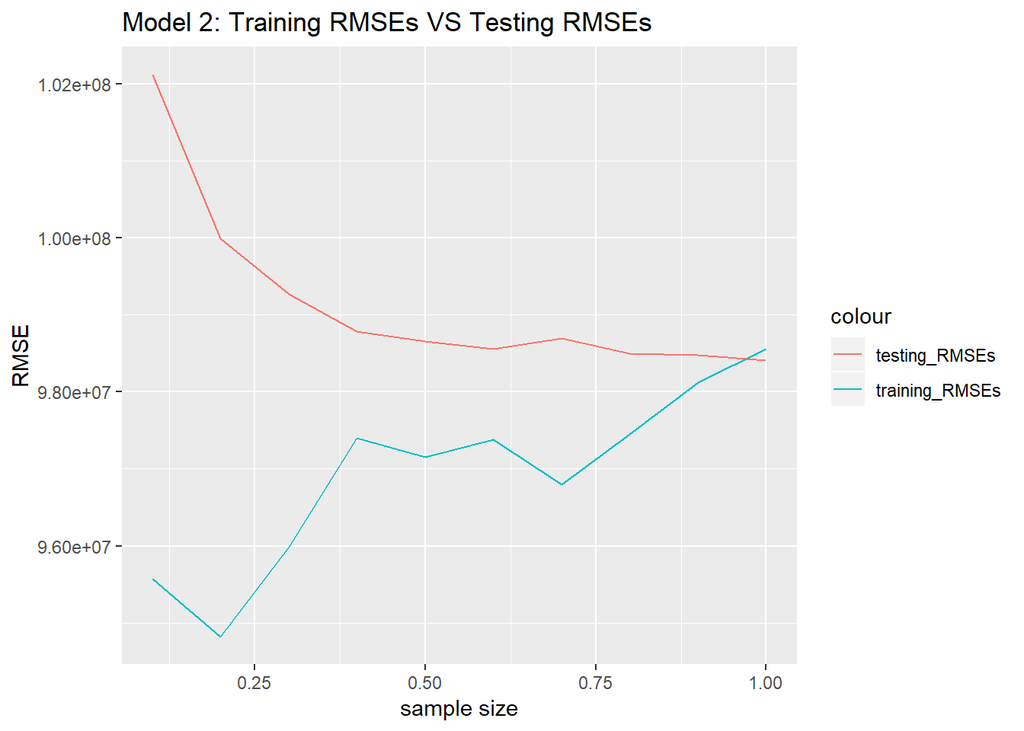

```r
ggplot(results, aes(sample_size)) +
  geom_line(aes(y=training_RMSEs, x=sample_size, colour="training_RMSEs")) +
  geom_line(aes(y=testing_RMSEs, x=sample_size, colour="testing_RMSEs")) +
  xlab("sample size") +
  ylab("RMSE") + labs(title="Model 2: Training RMSEs VS Testing RMSEs")
```

A log tranform was used for budget and imdbVotes and binning for tomatoRating. The scales of budget and imdbVotes are large compare with other variables, log transform can make the scales of budget and imdbvotes comparable with other variables. The binning on tomatoRating seems make the variable more discriminative, bining on other variables does not improve the performance.

As compared to Model 1 testing RMSE dropped from 100820138 to 98405746

### 4.3. Model 3 - Non-numeric variables

Convert genre, actors, directors, and other categorical variables to columns that can be used for regression. Process variables such as awards into more useful columns. Build a new model using these converted columns.

```r
# TODO: Build & evaluate model 3 (converted non-numeric variables only)

set.seed(42)
selected_features = c("Gross", "Genre", "Awards")
df_selected = subset(df_movie_gross_release_match, select = selected_features)
df_selected = df_selected[sample(nrow(df_selected)), ]

# transform binary genre variable
genre_df = data.frame(df_selected$Genre)
all_genre = apply(genre_df, 2, paste, collapse = ', ')
genre_dic_temp = unique(unlist(strsplit(all_genre, ', ')))
genre_dic = genre_dic_temp[genre_dic_temp!='N/A']
binary_genre = data.frame(matrix(0, nrow = length(df_selected$Genre), ncol = length(genre_dic)))
colnames(binary_genre) = genre_dic

for (i in 1:length(df_selected$Genre)){
  gener_i = df_selected$Genre[i]
  if(i%%10000 == 0)  print(gener_i)

  for (j in 1:length(genre_dic)){
    if(grepl(genre_dic[j], gener_i) == TRUE){
      binary_genre[i,j] = 1
    }
  }
}

df_selected = cbind(df_selected, binary_genre)
df_selected$Genre = NULL

# process Awards
df_selected$wins = as.numeric(str_extract(string = df_selected$Awards, "\\d+\\b(?=\\swin)"))
df_selected$wins[is.na(df_selected$wins)] = 0
# "Won {number}"
won = as.numeric(str_extract(string = df_selected$Awards, "(?<=Won\\s)\\d+"))
won[is.na(won)] = 0
df_selected$wins = df_selected$wins + won

# "{number} nominations"
df_selected$nominations = as.numeric(str_extract(string = df_selected$Awards, "\\d+\\b(?=\\snomination)"))
df_selected$nominations[is.na(df_selected$nominations)] = 0
# "Nominated for {number}"
nominated = as.numeric(str_extract(string = df_selected$Awards, "(?<=Nominated for\\s)\\d+"))
nominated[is.na(nominated)] = 0
df_selected$nominations = df_selected$nominations + nominated
df_selected$Awards = NULL

testing = df_selected[1 : (dim(df_selected)[1] * 0.2), ]
training = df_selected[(dim(df_selected)[1] * 0.2) : dim(df_selected)[1], ]
testing1 = na.omit(testing)
training1 = na.omit(training)

sample_size = c(0.1, 0.2, 0.3, 0.4, 0.5, 0.6, 0.7, 0.8, 0.9, 1)

training_rmses = matrix(0, nrow=10, ncol=10)
testing_rmses = matrix(0, nrow=10, ncol=10)

# start evaluation
for (i in 1:10) {
  # shuffle training
  training1 = training1[sample(nrow(training1)), ]
  for (j in 1:10) {
    # print((i-1)*10 + j)
    training_cur = training1[1:round(sample_size[j] * nrow(training1)), ]
    # print(summary(training_cur$tomatoFresh))
    # print(summary(testing1$tomatoFresh))

    res = estimate(training_cur, testing1)
    training_rmses[i, j] = res[[1]]
    testing_rmses[i, j] = res[[2]]
  }
}

# plot results
training_rmses = colMeans(training_rmses)
testing_rmses = colMeans(testing_rmses)

results = data.frame(cbind(sample_size, training_rmses, testing_rmses))
colnames(results) <- c("sample_size", "training_RMSEs", "testing_RMSEs")
print(min(testing_rmses))
```

```
## [1] 156769385
```

```r
print(which.min(testing_rmses))
```

```
## [1] 10
```

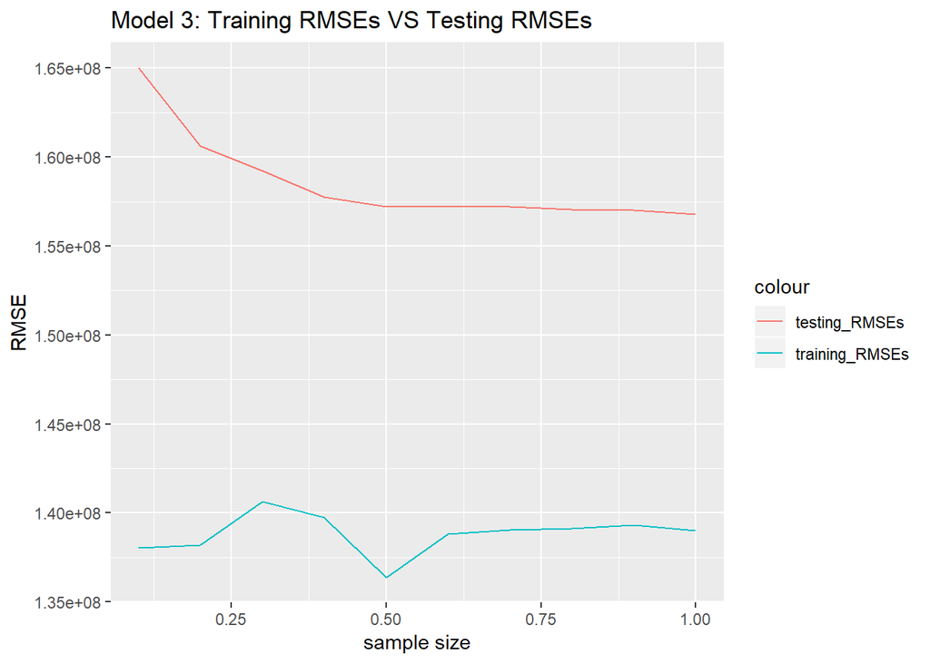

```r
ggplot(results, aes(sample_size)) +
  geom_line(aes(y=training_RMSEs, x=sample_size, colour="training_RMSEs")) +
  geom_line(aes(y=testing_RMSEs, x=sample_size, colour="testing_RMSEs")) +
  xlab("sample size") +
  ylab("RMSE") + labs(title="Model 3: Training RMSEs VS Testing RMSEs")
```

## 4.4. Model 4 - Numeric and categorical variables

Improve the prediction quality as much as possible by using both numeric and non-numeric variables from **Model 2 & 3**.

```r
# Build & evaluate model 4 (numeric & converted non-numeric variables)
set.seed(42)
selected_features = c("Gross", "Runtime", "imdbRating", "imdbVotes", "tomatoRating", "tomatoReviews", "tomatoFresh", "Budget", "Genre")
df_selected = subset(df_movie_gross_release_match, select = selected_features)
df_selected = df_selected[sample(nrow(df_selected)), ]

# convert non-numeric variables
# transform binary genre variable
genre_df = data.frame(df_selected$Genre)
all_genre = apply(genre_df, 2, paste, collapse = ', ')
genre_dic_temp = unique(unlist(strsplit(all_genre, ', ')))
genre_dic = genre_dic_temp[genre_dic_temp!='N/A']
binary_genre = data.frame(matrix(0, nrow = length(df_selected$Genre), ncol = length(genre_dic)))
colnames(binary_genre) = genre_dic

for (i in 1:length(df_selected$Genre)){
  gener_i = df_selected$Genre[i]
  if(i%%10000 == 0)  print(gener_i)

  for (j in 1:length(genre_dic)){
    if(grepl(genre_dic[j], gener_i) == TRUE){
      binary_genre[i,j] = 1
    }
  }
}

df_selected = cbind(df_selected, binary_genre)
df_selected$Genre = NULL


# numeric feature transform
testing = df_selected[1 : (dim(df_selected)[1] * 0.2), ]
training = df_selected[(dim(df_selected)[1] * 0.2) : dim(df_selected)[1], ]
testing1 = na.omit(testing)
training1 = na.omit(training)

# feature transformation
# log transform on budget
training1$LogBudget = log(training1$Budget)
testing1$LogBudget = log(testing1$Budget)
training1$LogimdbVotes = log(training1$imdbVotes)
testing1$LogimdbVotes = log(testing1$imdbVotes)

# binning on
training1$BintomatoRating = cut(training1$tomatoRating, 5, include.lowest = TRUE, labels = c(1, 2, 3, 4, 5))
testing1$BintomatoRating = cut(testing1$tomatoRating, 5, include.lowest = TRUE, labels = c(1, 2, 3, 4, 5))

# evaluation
testing = df_selected[1 : (dim(df_selected)[1] * 0.2), ]
training = df_selected[(dim(df_selected)[1] * 0.2) : dim(df_selected)[1], ]
testing1 = na.omit(testing)
training1 = na.omit(training)

sample_size = c(0.1, 0.2, 0.3, 0.4, 0.5, 0.6, 0.7, 0.8, 0.9, 1)

training_rmses = matrix(0, nrow=10, ncol=10)
testing_rmses = matrix(0, nrow=10, ncol=10)

# start evaluation
for (i in 1:10) {
  # shuffle training
  training1 = training1[sample(nrow(training1)), ]
  for (j in 1:10) {
    training_cur = training1[1:round(sample_size[j] * nrow(training1)), ]
    # print(summary(training_cur$tomatoFresh))
    # print(summary(testing1$tomatoFresh))

    res = estimate(training_cur, testing1)
    training_rmses[i, j] = res[[1]]
    testing_rmses[i, j] = res[[2]]
  }
}

# plot results
training_rmses = colMeans(training_rmses)
testing_rmses = colMeans(testing_rmses)

results = data.frame(cbind(sample_size, training_rmses, testing_rmses))
colnames(results) <- c("sample_size", "training_RMSEs", "testing_RMSEs")
print(min(testing_rmses))
```

```
## [1] 101838334
```

```r
print(which.min(testing_rmses))
```

```
## [1] 8
```

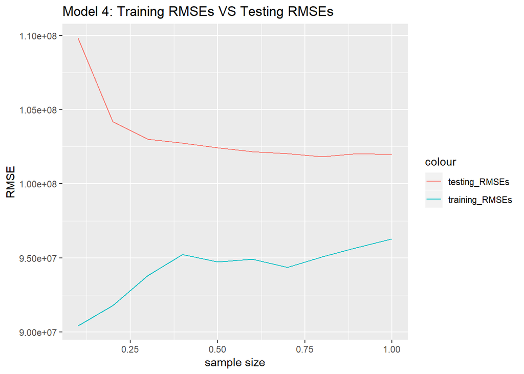

```r
ggplot(results, aes(sample_size)) +
  geom_line(aes(y=training_RMSEs, x=sample_size, colour="training_RMSEs")) +
  geom_line(aes(y=testing_RMSEs, x=sample_size, colour="testing_RMSEs")) +
  xlab("sample size") +
  ylab("RMSE") + labs(title="Model 4: Training RMSEs VS Testing RMSEs")
```

## 4.5. Model 5 - Additional features

Create additional features such as interactions or deeper analysis of complex variables tp build new model.

```r
#  Build & evaluate model 5 (numeric, non-numeric and additional features)
set.seed(42)
selected_features = c("Gross", "Runtime", "imdbRating", "imdbVotes", "tomatoRating", "tomatoReviews", "tomatoFresh", "Budget", "Genre", "Awards")
df_selected = subset(df_movie_gross_release_match, select = selected_features)
df_selected = df_selected[sample(nrow(df_selected)), ]

# convert non-numeric variables
# transform binary genre variable
genre_df = data.frame(df_selected$Genre)
all_genre = apply(genre_df, 2, paste, collapse = ', ')
genre_dic_temp = unique(unlist(strsplit(all_genre, ', ')))
genre_dic = genre_dic_temp[genre_dic_temp!='N/A']
binary_genre = data.frame(matrix(0, nrow = length(df_selected$Genre), ncol = length(genre_dic)))
colnames(binary_genre) = genre_dic

for (i in 1:length(df_selected$Genre)){
  gener_i = df_selected$Genre[i]
  if(i%%10000 == 0)  print(gener_i)

  for (j in 1:length(genre_dic)){
    if(grepl(genre_dic[j], gener_i) == TRUE){
      binary_genre[i,j] = 1
    }
  }
}

df_selected = cbind(df_selected, binary_genre)
df_selected$Genre = NULL

# process Awards
df_selected$wins = as.numeric(str_extract(string = df_selected$Awards, "\\d+\\b(?=\\swin)"))
df_selected$wins[is.na(df_selected$wins)] = 0
# "Won {number}"
won = as.numeric(str_extract(string = df_selected$Awards, "(?<=Won\\s)\\d+"))
won[is.na(won)] = 0
df_selected$wins = df_selected$wins + won

# "{number} nominations"
df_selected$nominations = as.numeric(str_extract(string = df_selected$Awards, "\\d+\\b(?=\\snomination)"))
df_selected$nominations[is.na(df_selected$nominations)] = 0
# "Nominated for {number}"
nominated = as.numeric(str_extract(string = df_selected$Awards, "(?<=Nominated for\\s)\\d+"))
nominated[is.na(nominated)] = 0
df_selected$nominations = df_selected$nominations + nominated
df_selected$Awards = NULL

# numeric feature transform
testing = df_selected[1 : (dim(df_selected)[1] * 0.2), ]
training = df_selected[(dim(df_selected)[1] * 0.2) : dim(df_selected)[1], ]
testing1 = na.omit(testing)
training1 = na.omit(training)

# feature transformation
# log transform on budget
training1$LogBudget = log(training1$Budget)
testing1$LogBudget = log(testing1$Budget)
training1$LogimdbVotes = log(training1$imdbVotes)
testing1$LogimdbVotes = log(testing1$imdbVotes)

# binning on
training1$BintomatoRating = cut(training1$tomatoRating, 5, include.lowest = TRUE, labels = c(1, 2, 3, 4, 5))
testing1$BintomatoRating = cut(testing1$tomatoRating, 5, include.lowest = TRUE, labels = c(1, 2, 3, 4, 5))

# add additional features
training1$is_budget_greater_than_3M <- ifelse(training1$Budget > 3000000, 1, 0)
testing1$is_budget_greater_than_3M <- ifelse(testing1$Budget > 3000000, 1, 0)
training1$is_imdbRating <- ifelse(training1$imdbRating > 6.5, 1, 0)
testing1$is_imdbRating <- ifelse(testing1$imdbRating > 6.5, 1, 0)

# evaluation
testing = df_selected[1 : (dim(df_selected)[1] * 0.2), ]
training = df_selected[(dim(df_selected)[1] * 0.2) : dim(df_selected)[1], ]
testing1 = na.omit(testing)
training1 = na.omit(training)

sample_size = c(0.1, 0.2, 0.3, 0.4, 0.5, 0.6, 0.7, 0.8, 0.9, 1)

training_rmses = matrix(0, nrow=10, ncol=10)
testing_rmses = matrix(0, nrow=10, ncol=10)

# start evaluation
for (i in 1:10) {
  # shuffle training
  training1 = training1[sample(nrow(training1)), ]
  for (j in 1:10) {
    training_cur = training1[1:round(sample_size[j] * nrow(training1)), ]
    # print(summary(training_cur$tomatoFresh))
    # print(summary(testing1$tomatoFresh))

    res = estimate(training_cur, testing1)
    training_rmses[i, j] = res[[1]]
    testing_rmses[i, j] = res[[2]]
  }
}

# plot results
training_rmses = colMeans(training_rmses)
testing_rmses = colMeans(testing_rmses)

results = data.frame(cbind(sample_size, training_rmses, testing_rmses))
colnames(results) <- c("sample_size", "training_RMSEs", "testing_RMSEs")
print(min(testing_rmses))
```

```
## [1] 102820629
```

```r
print(which.min(testing_rmses))
```

```
## [1] 8
```

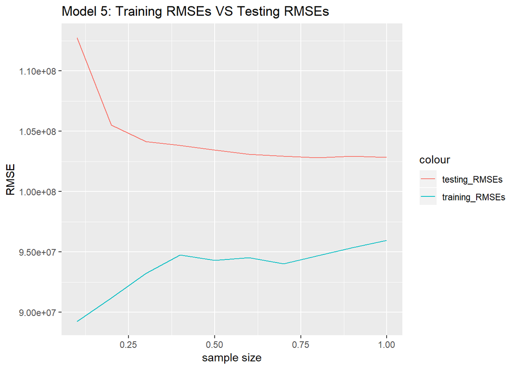

```r
ggplot(results, aes(sample_size)) +
  geom_line(aes(y=training_RMSEs, x=sample_size, colour="training_RMSEs")) +
  geom_line(aes(y=testing_RMSEs, x=sample_size, colour="testing_RMSEs")) +
  xlab("sample size") +
  ylab("RMSE") + labs(title="Model 5: Training RMSEs VS Testing RMSEs")
```

The final RMSE is 102820629.